# 02-monte-carlo-error

Yasi Wang

10/27/2019

# Introduction

Simulations is very useful, which gives us insight into the outcome of a given situation. When we run the simulation multiple times, different results are obtained. This between-simulation variability is called **Monte Carlo error**.

Specifically, there are two primary ways in which simulation error is measured: absolute error and relative error. **Absolute error** is the magnitude of the difference between the exact value and the approximation. **Relative error** is the absolute error divided by the magnitude of the exact value.

In this blog, I’d like to show you the concepts of absolute error and relative error when estimating probabilities from simulation.

# Simulation

In the simulation, I performed a 14 X 5 factorial experiment simulation that estimates the error for each combination of replicate number (2<sup>2</sup>, 2<sup>3</sup>, …, 2<sup>15</sup>) and probability (0.01, 0.05, 0.10, 0.25, 0.50).

### 1) One series of simulation with p = .50

We can start with doing one series of simulation with p = .50. First, We made two vectors that can store absolute error and relative error. Then, we did for loop to get the value of abs_error and rel_error in each condition. We found that as N increase, absolute error and relative error both decrease.

[output not shown]

```r
set.seed(123)
p <- .50
abs_error <- rel_error <- rep(NA, 14)
n = 2
for (i in seq_along(abs_error)) {
  n <- n * 2
  abs_error[i] <- mean(abs(rbinom(1000, n, p)/n - p))
  rel_error[i] <- abs_error[i]/p
}
par(mfrow = c(1, 2))
label <- c(2^2, 2^3, 2^4, 2^5,2^6, 2^7, 2^8, 2^9, 2^10, 2^11, 2^12, 2^13, 2^14, 2^15)
plot(abs_error, col = "orange", type = "b", xaxt = "n", xlab = ("N"~(log[2]~"scale")), ylab = "Absolute Error", pch=16, lwd = 4, main = "Absolute error with N (p = .50)")
axis(1, at = 1:14, labels = label, las = 2)
```

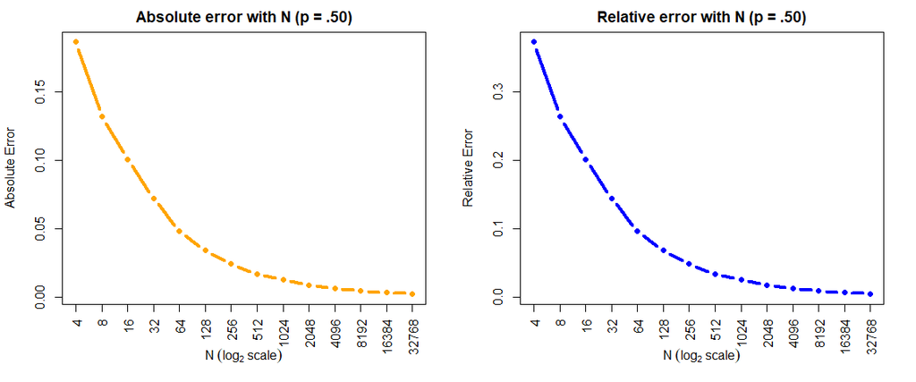

```r
plot(rel_error, col = "blue", type = "b", xaxt = "n", xlab = ("N"~(log[2]~"scale")), ylab = "Relative Error", pch=16, lwd = 4, main = "Relative error with N (p = .50)")
axis(1, at = 1:14, labels = label, las = 2)
```

### 2) Simulations with multiple p

After generating one plot, now we start to do the simulation with multiple p values. Different from previous method, here I created two matrices with 5 rows and 14 columns to store the abs_errors and rel_errors. The code is demonstrated below. In the first for loop, j represented probability choices. In the second loop, i can control the simulation times. Most interestingly, I added one more loop, which could enable us to get the stable probability of abs_error and rel_error in one series of simulation.

```r
# method 1
set.seed(10)
p <- c(.50, .25, .10, .05, .01)
abs_error <- rel_error <- matrix(nrow = 5, ncol = 14)
for (j in seq(1, 5)) {
  n = 2
  for (i in seq(1, 14)) {
    n <- n * 2
    tmp_abs_error <- 0
    for (k in seq(1, 1000)) {
      p_hat <- rbinom(1, n, p[j])/n
      tmp_abs_error <- tmp_abs_error + abs(p[j] - p_hat)
    }

    abs_error[j,i] <- tmp_abs_error/1000
    rel_error[j,i] <- abs_error[j,i]/p[j]
  }
}
```

The scatter plot are shown below. We can find that with N increase, absolute error will decrease. And the larger the p value, the larger absolute error it is.

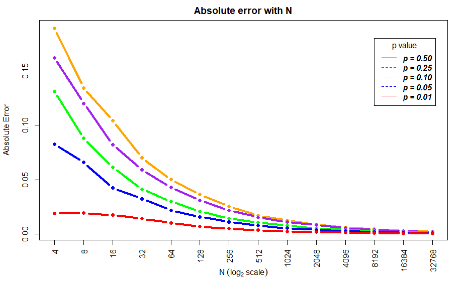

As for relative error, we can find that with N increase, error will decrease. And the larger the p value, the smaller error.

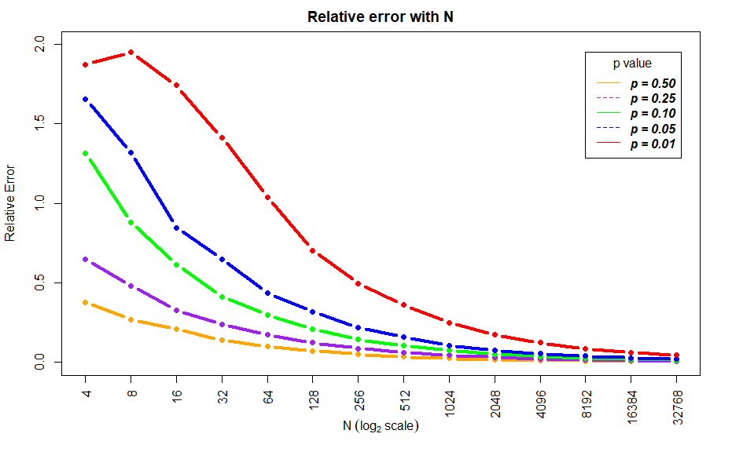

### 3) Further exploration

I scale $log10$ to the y-axis. Let’s see what will happen.

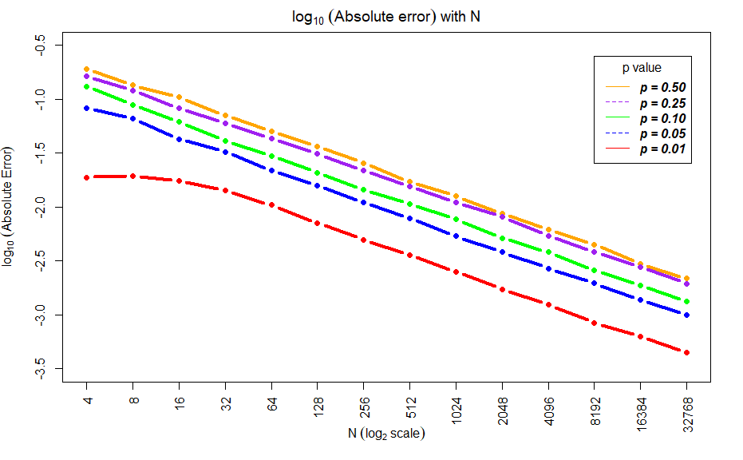

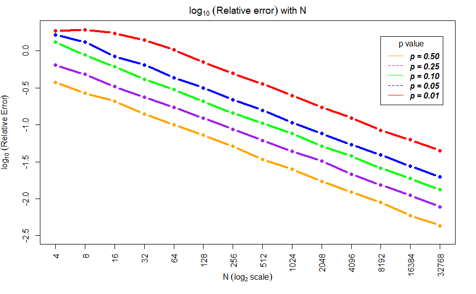

If we change y-axis is on the $log10$ scale, we can found that there is a liner relationship between Absolute error/Relative error and N.